# 19andMe and Nexoid Covid Risk Comparison

Jennifer Starling @ Mathematica

2021-03-10

## Goal: Compare the risk predictions for 19andMe versus the Nexoid covid risk calculator.

The NExoid Covid-19 risk calculator is available at https://www.covid19survivalcalculator.com.

## Mortality risk comparison.

### Overall.

We first compare the risk of mortality P(death) for 19andMe versus Nexoid. We plot mortality risk for Nexoid versus 19andMe, with colour indicating observations where

- 19andMe and Nexoid reported mortality risk within 10% of each other (black)
- 19andMe mortality risk was more than 10% higher than Nexoid (blue)
- 19andMe mortality risk was more than 10% lower than Nexoid (orange)

The Spearman ranked correlation coefficient for $\text{cor}[P_{19}(death), P_{nex}(death)]$ is 0.91.

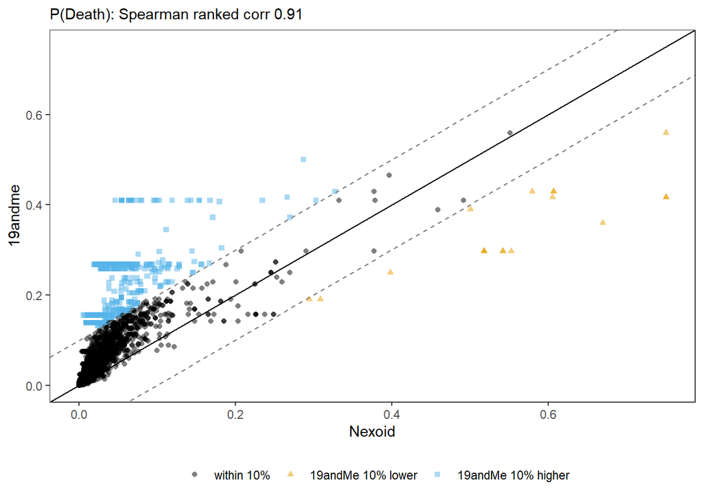

```r
# Plot 19andMe versus Nexoid death risks.
ggplot(df, aes(x=nexoid_risk_mortality, y=api_death_risk, colour=death_check, shape=death_check)) +
  geom_point(alpha=.5) +
  coord_cartesian(xlim=c(0,.75), ylim=c(0,.75)) +
  geom_abline(intercept=0, slope=1, colour='black') +
  geom_abline(intercept=-.1, slope=1, colour='grey50', linetype=2) +
  geom_abline(intercept=.1, slope=1, colour='grey50', linetype=2) +
  scale_colour_colorblind(name='') +
  scale_shape_discrete(name='') +
  labs(x='Nexoid', y='19andme',
       subtitle=paste0('P(Death): Spearman ranked corr ', spearman_cor))+
  theme_bw() + theme(panel.grid.major = element_blank(), panel.grid.minor = element_blank(), legend.position='bottom')
```

```r
ggsave(file.path("..", "figures", "figure-mortality-01.pdf"), height=5, width=8)
```

The mortality risk reported by the two apps are largely consistent, with only

- 18 observations where 19andMe’s mortality risk was more than 10% lower than Nexoid’s, and
- 757 observations where 19andMe’s mortality risk was more than 10% higher than Nexoid’s

where n=51799. Proportions are below.

```r
print(my_props)
```

```
        within 10%  19andMe 10% lower 19andMe 10% higher
            0.9850             0.0003             0.0146
```

We focus on raw difference in mortality rate over ratios for reasons illustrated below.

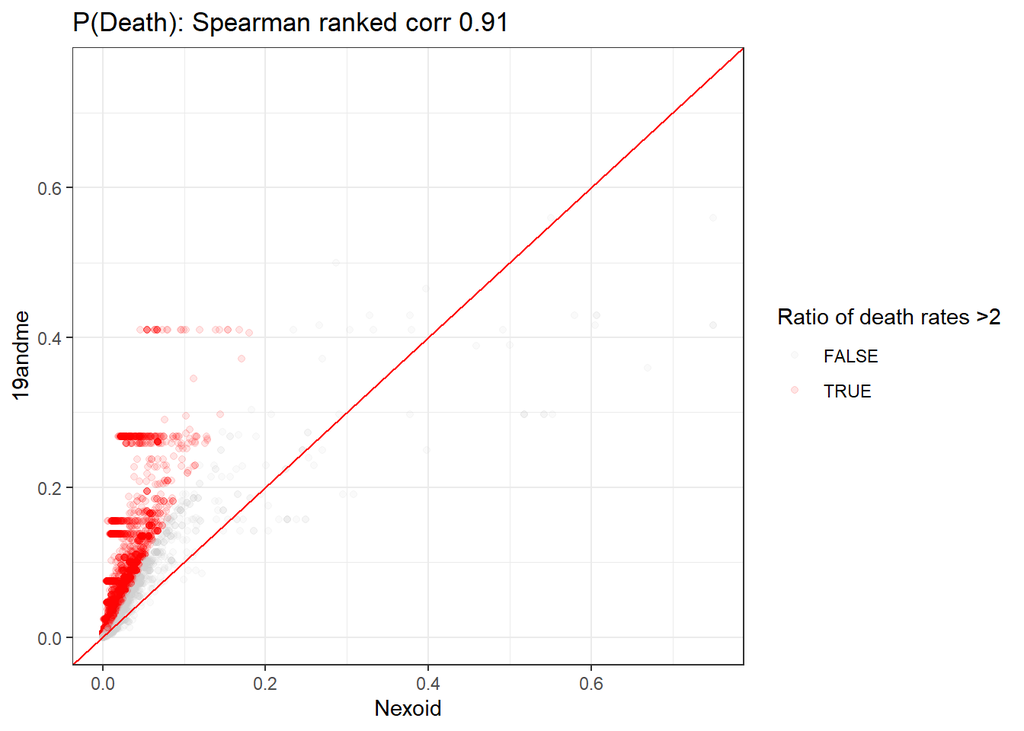

```r
# Note: The ratios really don't seem to be the way to go here.  If you look at the colour here
# for ratio more than two, it captures a lot of small values where the ratio is large, but practical
# magnitude of the difference is very small.  (I.e. P(death)=.8 versus .4 - we wouldn't care about this.)
ggplot(df, aes(x=nexoid_risk_mortality, y=api_death_risk, colour=factor(abs(death_diff_ratio)>2))) +
  geom_point(alpha=.1) +
  coord_cartesian(xlim=c(0,.75), ylim=c(0,.75)) +
  geom_abline(intercept=0, slope=1, colour='red') +
  labs(x='Nexoid', y='19andMe', title='P(Death)') +
  scale_colour_manual(name='Ratio of death rates >2', values=c('grey80', 'red')) +
  labs(x='Nexoid', y='19andme',
       title=paste0('P(Death): Spearman ranked corr ', spearman_cor))+
  theme_bw()
```

```r
ggsave(file.path("..", "figures", "figure-mortality-02.pdf"), height=5, width=8)
```

### Age.

Now, we investigate the sources of the larger-than-10% differences highlighted in orange and blue. First, we examine these differences by age.

- There are no large differences in the under-60 cohort.
- Cases where 19andMe is more than 10% lower are isolated to the 80+ age group, while
- Cases where 19andMe is over 10% higher increase with age across the over-60 cohort.

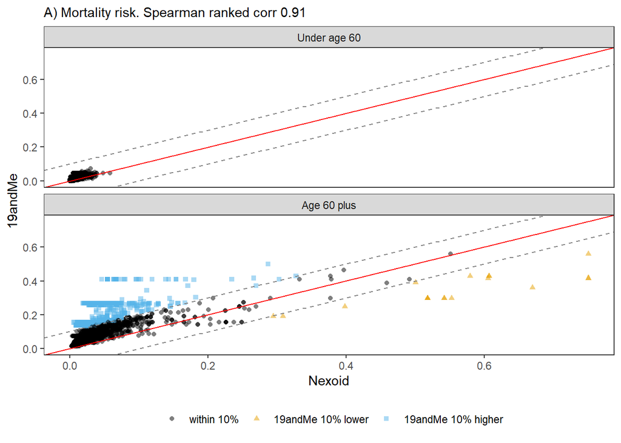

```r
# Age
paper_plt1_panel1 = ggplot(df %>% mutate(age_cat = factor(ifelse(age<60, 'Under age 60', 'Age 60 plus'),
                                                          levels=c('Under age 60', 'Age 60 plus'))),
       aes(x=nexoid_risk_mortality, y=api_death_risk, colour=death_check, shape=death_check)) +
  geom_point(alpha=.5) +
  coord_cartesian(xlim=c(0,.75), ylim=c(0,.75)) +
  geom_abline(intercept=0, slope=1, colour='red') +
  labs(x='Nexoid', y='19andMe', subtitle=paste0('A) Mortality risk. Spearman ranked corr ', spearman_cor))+
  facet_wrap(~age_cat, ncol=1) +
  scale_colour_colorblind(name='') +
  scale_shape_discrete(name='') +
  geom_abline(intercept=-.1, slope=1, colour='grey50', linetype=2) +
  geom_abline(intercept=.1, slope=1, colour='grey50', linetype=2) +
  theme_bw() + theme(panel.grid.major = element_blank(), panel.grid.minor = element_blank(),
                     legend.position='bottom')
ggsave(file.path("..", "figures", "figure-mortality-03.pdf"), paper_plt1_panel1, height=8, width=6)
paper_plt1_panel1
```

The Nexoid app uses a mortality rate adjustment factor of 2.09 for 60-70, 4.77 for 70-80, and 12.64 for age 80+, so these findings are not surprising.

### 19andMe risk more than 10% lower.

The cases where 19andMe has death risk at least 10% lower than Nexoid are in the 60+ age category.

The 19andme app does not include race. Let’s see if that is a source of discrepancy in the over-60 cohort.

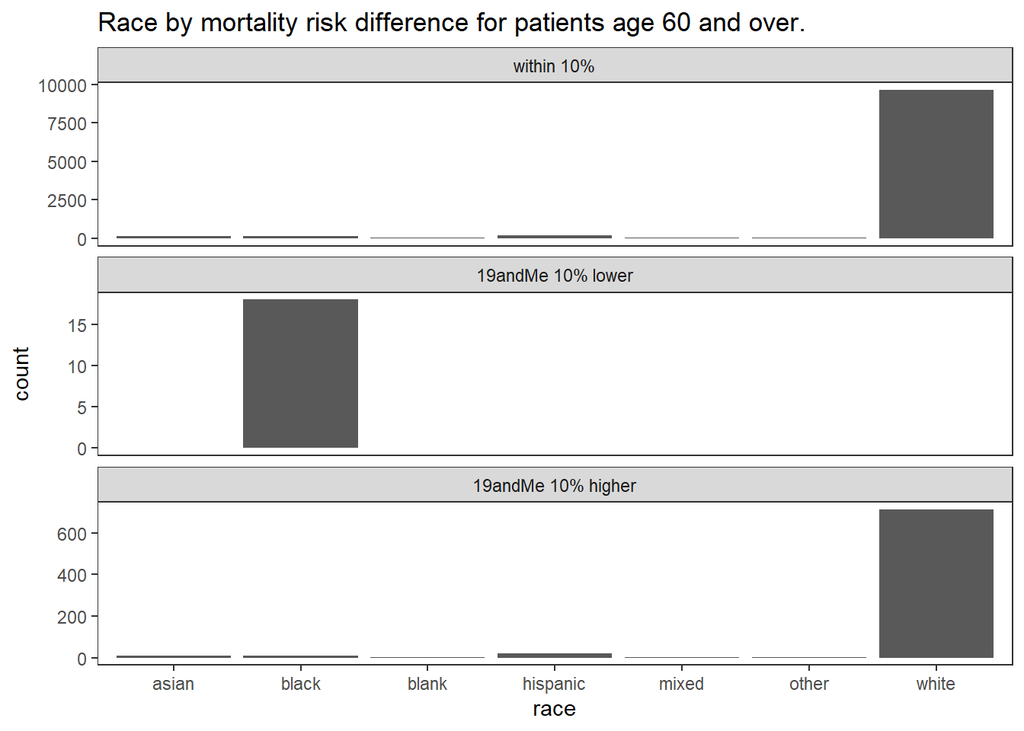

```r
# The 10% diff cases show up only in the 60+ population.  Let's dig in.
df_60plus = df %>% filter(age>=60)

# Let's see if race plays a factor.
ggplot(df_60plus, aes(x=race)) +
  geom_bar() +
  facet_wrap(~death_check,ncol=1, scales='free_y') +
  labs(title='Race by mortality risk difference for patients age 60 and over.') +
  theme_bw() +
  theme(panel.grid.major = element_blank(), panel.grid.minor = element_blank())
```

```r
ggsave(file.path("..", "figures", "figure-mortality-04.pdf"), height=5, width=6)
```

Below is the age distribution for black patients in the entire dataset, by magnitude of mortality risk difference. All 18 of the cases where 19andMe is 10% or more lower are black patients over 80.

The p-value for the Chi-squared test is <0.001; we reject the null hypotehsis that the distribution of race is the same in the different mortality difference groups.

```r
xtabs(~age+death_check, df %>% filter(race=='black'))
```

```
    death_check
age  within 10% 19andMe 10% lower 19andMe 10% higher
  0           6                 0                  0
  10        193                 0                  0
  20        283                 0                  0
  30        225                 0                  0
  40        143                 0                  0
  50        124                 0                  0
  60         60                 0                  1
  70         31                 0                  4
  80         31                18                  4
```

These 18 cases have much higher Nexoid mortality risk than what 19andMe is estimating; let’s perform a thought experiment.

- We take these 18 cases and find similar patients in the dataset who are not Black, and obtain those matched Nexoid mortality risk scores.
- We see that this ad-hoc adjustment for the effect of Blackness in the Nexoid mortality risk calculation brings the risk scores in-line.
- In other words, switching a patient from Black to not-Black decreases the Nexoid mortality risk to levels comparable with other observations in the over-60 cohort.

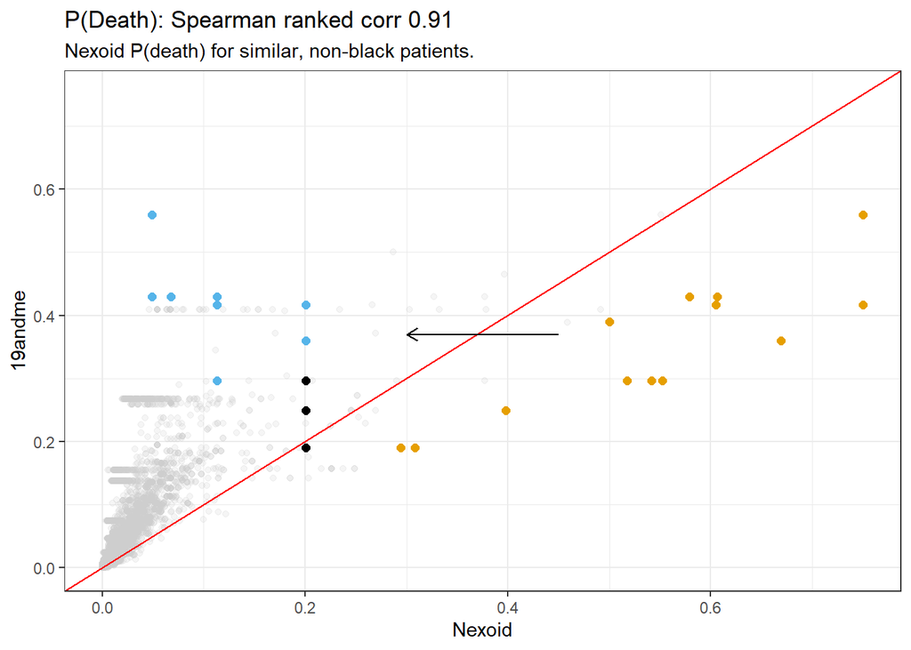

Once we make this adjustment, 19andme is again estimating similar or slightly higher mortality risk, as we do for many of the over-60 patients. The adjusted patients who are now blue (difference larger than 10%) generally

- have large numbers of contacts,
- have pre-existing conditions, and
- unanimously do not follow CDC hand-washing or PPE guidelines.

Next, we will see what factors contribute to the larger positive differences.

### 19andMe more than 10% higher.

We will now investigate what factors contribute to 19andMe reporting higher mortality rates. These cases are again in the over-60 cohort.

Pre-existing conditions look to matter; the distribution of number of pre-existing conditions is higher for patients where 19andMe is estimating at least 10% higher mortality risk than Nexoid.

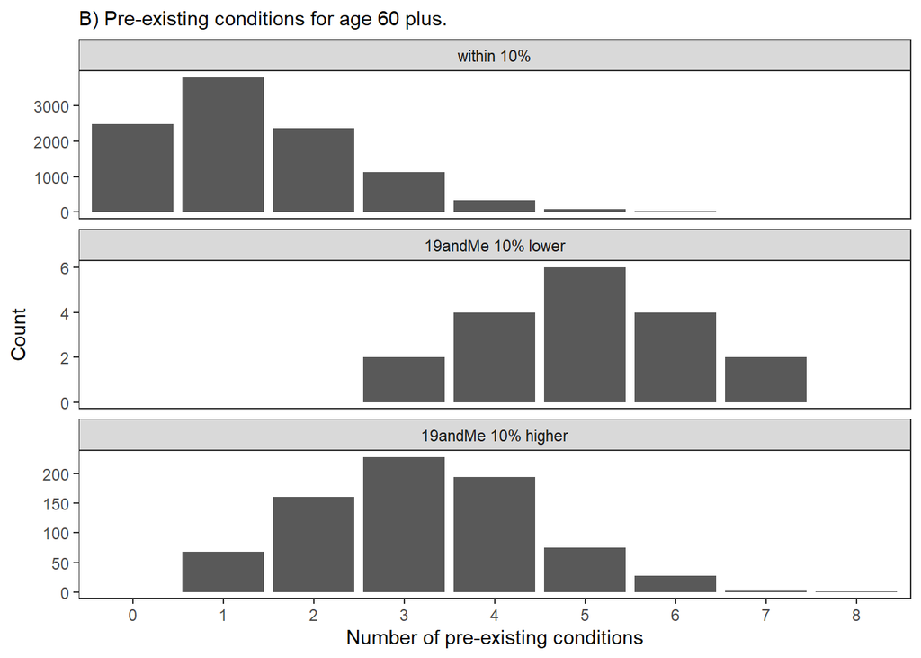

We use a Wilcoxon test to compare the mean number of pre-existing conditions in within-10% verus over-10% difference groups, for the over-60 cohort. The p-value is < 0.001; we reject the null hypotehsis that the mean number of pre-existing conditions in the within-10% and the over-10% difference groups are the same.

In the Nexoid mortality calculations, heart disease (1.27), kidney disease (1.72), immune disease (1.67), and diabetes (1.87) have higher adjustment factors, while the hypertension (0.95) adjustment factor is lower.

Note: These are the “The below table shows the factors used in the mortality calculation”, but not exactly sure how that adjustment is being made.

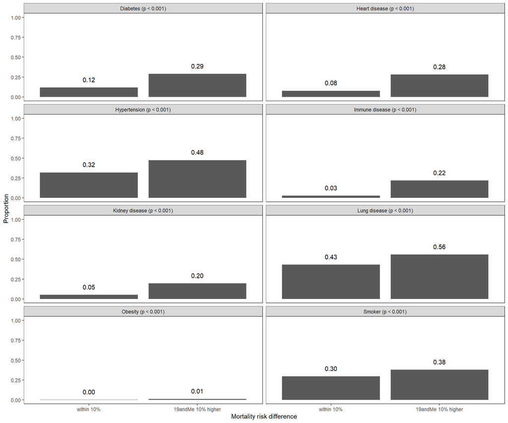

Employment status does not look meaningfully different in the risk-difference groups.

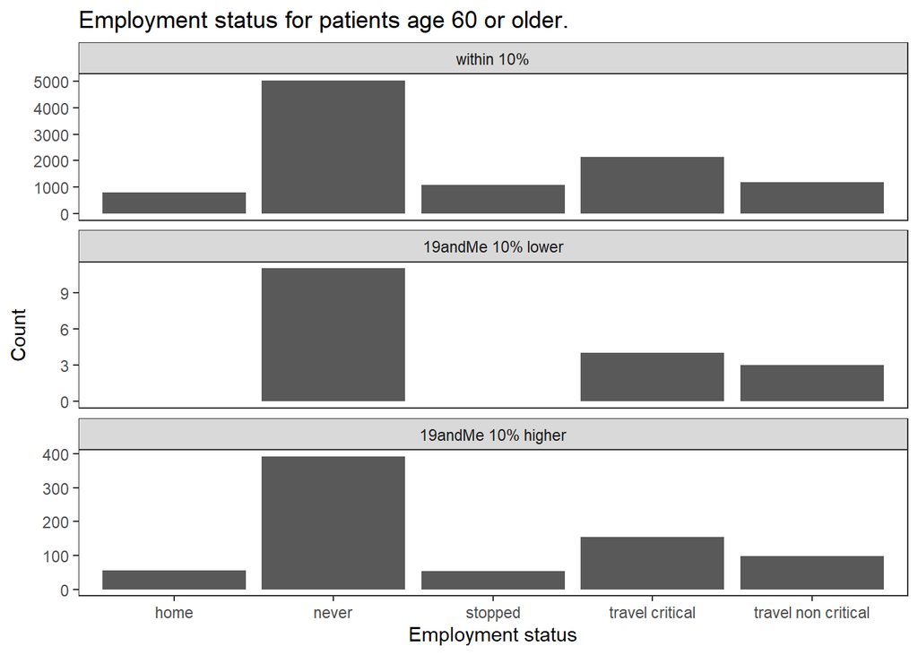

The p-value for the Chi-squared test is 0.0803; we do not find evidence of difference in distribution of employment conditions across in the different mortality difference groups.

Presence of Covid symptoms is also higher for the cohort where 19andMe estimates at least 10% higher risk. This is a tricky category to truly assess:

- 19andMe provides a list of symptoms which can be selected in combination, while
- Nexoid has a single checkbox to indicate presence of Covid symptoms (dry cough and fever).

Since 19andMe’s symptom list does not include fever, we a Nexoid symptoms selection to “is_other” in the API.

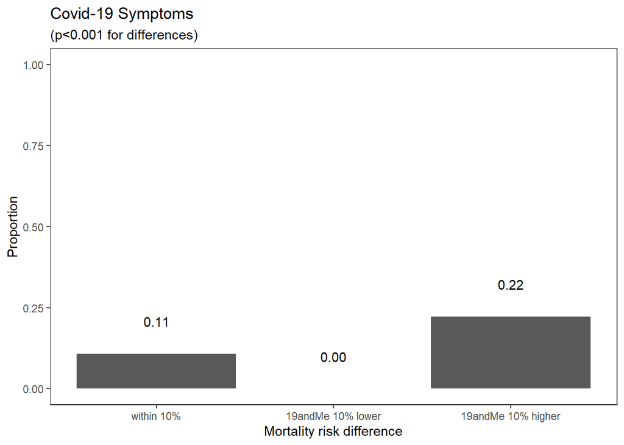

### Mortality risk conclusions.

1. For patients under 60, all estimated death risks are within 10% for 19andMe vs Nexoid.
2. For patients over 60, 19andMe is giving lower estimates for Black patients, as we do not consider race.
3. For patients over 60, 19andMe is estimating higher death risks when there are multiple pre-existing conditions or when there are symptoms. (is_other is only symptom we are able to check against.)

## Exposure risk comparison.

### Overall.

We now compare the risk of exposure P(exposure) for 19andMe versus Nexoid.

- Nexoid calculates P(exposure) for all time, while 19andMe calculates risk of exposure in a week.
- We calculate a per-week P(exposure) for Nexoid as
  - $P_{nex}(exposure)/nweeks$, where
  - $nweeks=33$ is the number of weeks in the dataset.

We plot weekly exposure risk for Nexoid versus 19andMe, with colour indicating observations where with colour indicating observations where

- 19andMe and Nexoid reported exposure risk within 1% of each other (black)
- 19andMe exposure risk was more than 1% higher than Nexoid (blue)
- 19andMe exposure risk was more than 1% lower than Nexoid (orange)

We are using 1% instead of 10% for a comparison threshold due to the narrower range of P(exposure).

The Spearman ranked correlation coefficient for $corr[P_{19}(exposure), P_{nex}(exposure)]$ is 0.457.

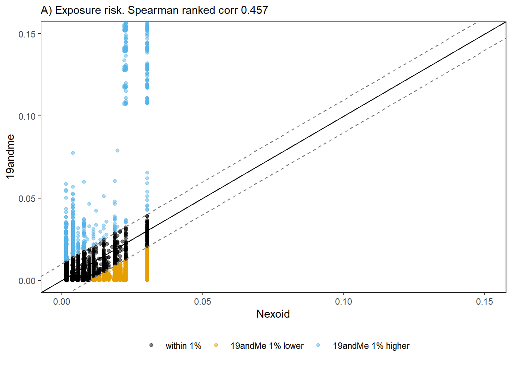

```r
# Plot 19andMe versus Nexoid exposure risks.
paper_plt2_panel1 = ggplot(df, aes(x=nexoid_risk_infection_wk, y=api_exposure_risk, colour=exp_check)) +
  geom_point(alpha=.5) +
  coord_cartesian(xlim=c(0,.15), ylim=c(0,.15)) +
  geom_abline(intercept=0, slope=1, colour='black') +
  geom_abline(intercept=-.01, slope=1, colour='grey50', linetype=2) +
  geom_abline(intercept=.01, slope=1, colour='grey50', linetype=2) +
  scale_colour_colorblind(name='') +
  labs(x='Nexoid', y='19andme',
       subtitle=paste0('A) Exposure risk. Spearman ranked corr ', spearman_cor))+
  theme_bw()+ theme(panel.grid.major = element_blank(), panel.grid.minor = element_blank(),
                     legend.position='bottom')
ggsave(file.path("..", "figures", "figure-exposure-01.pdf"), paper_plt2_panel1, height=5, width=8)
paper_plt2_panel1
```

We find that the exposure risks are generally aligned between 19andMe and Nexoid:

- 78.38% of the exposure risks are within 1%
- 90.17% are within 2.5%
- 93.65% are within 5%

Proportions for the 1% threshold are below.

```r
print(my_props)
```

```
        within 1%  19andMe 1% lower 19andMe 1% higher
           0.7838            0.1360            0.0802
```

### 19andMe more than 1% higher.

Nexoid adjusts for >9 primary contacts by increasing risk 9%, and for >17 contacts by increasing risk 14% (red lines). Secondary contacts >10 increase Nexoid risk by 38%.

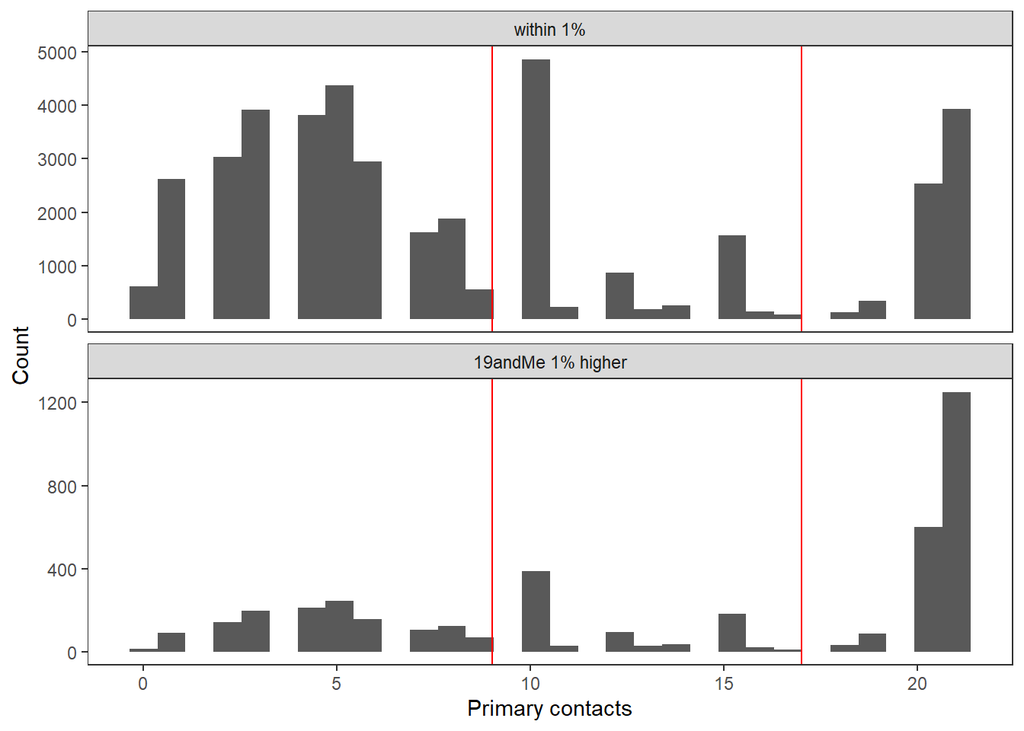

```r
# Number of primary contacts
ggplot(df %>% filter(exp_check!='19andMe 1% lower'), aes(x=nppl)) +
  geom_histogram() +
  geom_vline(aes(xintercept=9), colour='red') +
  geom_vline(aes(xintercept=17), colour='red') +
  facet_wrap(~exp_check, ncol=1, scales="free_y") +
  labs(y='Count', x='Primary contacts') +
  theme_bw() +
  theme(panel.grid.major = element_blank(), panel.grid.minor = element_blank())
```

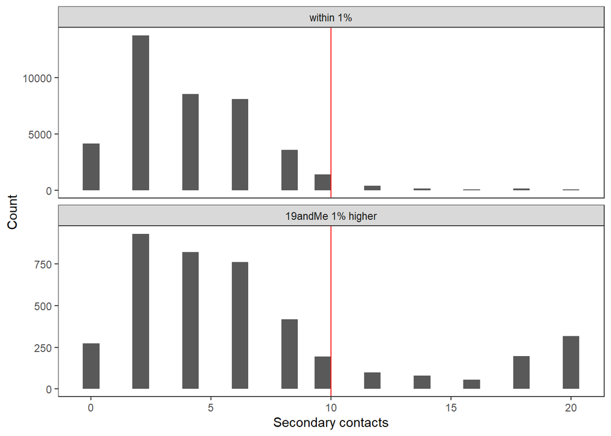

```r
ggsave(file.path("..", "figures", "figure-exposure-02a.pdf"), height=5, width=6)

# Number of secondary contacts.
ggplot(df %>% filter(exp_check!='19andMe 1% lower'), aes(x=nppl2)) +
  geom_histogram() +
    geom_vline(aes(xintercept=10), colour='red') +
  facet_wrap(~exp_check, ncol=1, scales="free_y") +
  labs(x='Secondary contacts', y='Count') +
  theme_bw() +
  theme(panel.grid.major = element_blank(), panel.grid.minor = element_blank())
```

```r
ggsave(file.path("..", "figures", "figure-exposure-02b.pdf"), height=5, width=6)

# ADD FIGURE FOR PAPER
paper_plt2_panel2 =
  # Rbind together each table of proportions for within vs higher, for primary and secondary.
  rbind(
    data.frame(prop.table(xtabs(~nppl+exp_check, data=df %>%
      filter(exp_check!='19andMe 1% lower') %>%
      select(nppl, exp_check), drop.unused.levels=T), margin=2)) %>%
      rename(contacts=nppl, prop=Freq) %>%
      mutate(contact_type = 'Primary contacts'),
    data.frame(prop.table(xtabs(~nppl2+exp_check, data=df %>%
      filter(exp_check!='19andMe 1% lower') %>%
      select(nppl2, exp_check), drop.unused.levels=T), margin=2)) %>%
      rename(contacts=nppl2, prop=Freq) %>%
      mutate(contact_type = 'Secondary contacts')
  ) %>%
  ggplot(aes(x=contacts, y=prop, fill=exp_check)) +
  geom_bar(position='dodge', stat='identity') +
  facet_wrap(~contact_type, ncol=1, scale='free_y') +
  labs(x='Number of contacts', y='Proportion',
       subtitle='B) Distributions of contacts by exposure risk difference.') +
  scale_fill_manual(name='', values=c('grey30', 'grey70')) +
  theme_bw() +
  theme(panel.grid.major = element_blank(), panel.grid.minor = element_blank(), legend.position='bottom')

# ASSEMBLE EXPOSURE PANEL
panel2 = plot_grid(paper_plt2_panel1, paper_plt2_panel2, ncol=2)
ggsave(file.path("..", "figures", "_paper-val-fig2.jpg"), plot(panel2), height=5, width=9.5)
ggsave(file.path("..", "figures", "_paper-val-fig2.pdf"), plot(panel2), height=5, width=9.5)
```

We use Wilcoxon tests to compare the mean number of primary and secondary contacts in within-1% verus over-1% difference groups. The p-values (Bonferroni-adjusted) are < 0.001 for primary contacts, and < 0.001 for secondary contacts; we reject the null hypotheses that the mean number of primary contacts and the mean number of seconary contacts are the same in the within-1% and the over-1% difference groups.

Additionally, both hand-washing and PPE are under-represented in the group where 19andMe exposure risk is more than 1% higher.

- 19andme is adjusting odds ratios by .45 for hand-washing and .32 for PPE, while
- Nexoid is not making adjustments for either.

The plot below shows the proportions of hand-washer and mask-wearers in the 1% higher group versus other groups.

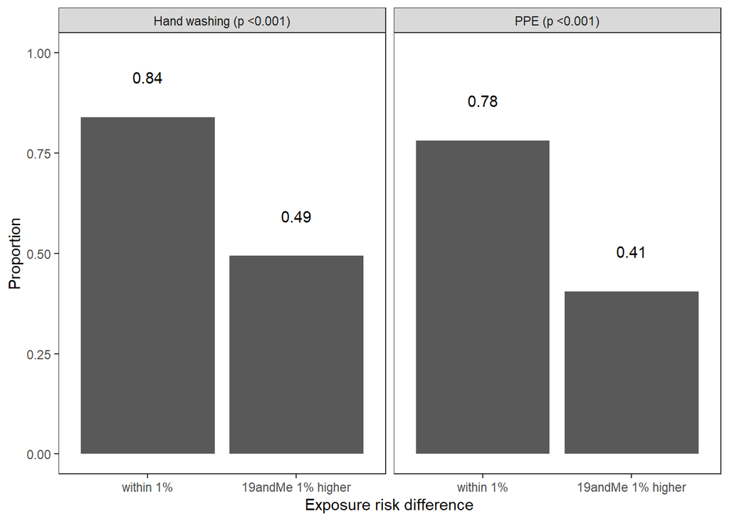

```r
# Handwashing and PPE proportions.

# Process data to get counts for each condition.
temp <- df %>%
  filter(exp_check!="19andMe 1% lower") %>%
  group_by(exp_check) %>%
  dplyr::summarise(hand = sum(hand),
                   ppe = sum(ppe), n=n()) %>%
  pivot_longer(hand:ppe, names_to='condition', values_to='x') %>%
  mutate(p = x/n) %>%
  arrange(condition)

# Calculate p-values and adjust for multiple comparisons (Bonferroni).
pvals = p.adjust(c(
    prop.test(x =  temp %>% filter(condition=='hand') %>% pull(x),
            n = temp %>% filter(condition=='hand') %>% pull(n))$p.value,
    prop.test(x =  temp %>% filter(condition=='ppe') %>% pull(x),
            n = temp %>% filter(condition=='ppe') %>% pull(n))$p.value
  ))
temp$pvals = format.pval(rep(pvals, each=2), digits=3, eps=1e-3)
rm(pvals)

# Add labels for conditions.
temp$facets = rep(c('Hand washing', 'PPE'), each=2)

ggplot(temp, aes(x=exp_check, y=p, label=format(round(p,2), nsmall=2, digits=2))) +
  geom_bar(stat='identity') +
  geom_text(aes(y=p+.1)) +
  coord_cartesian(ylim=c(0,1)) +
  facet_wrap(~paste0(facets, " (p ", pvals, ')'), ncol=2) +
  labs(x='Exposure risk difference', y = 'Proportion') +
  theme_bw()+
  theme(panel.grid.major = element_blank(), panel.grid.minor = element_blank())
```

```r
ggsave(file.path("..", "figures", "figure-exposure-03.pdf"), height=5, width=6)
```

The p-values for a chi-squared tests are < 0.001 for hand-washing, and < 0.001 for PPE, giving significant evidence of different proportions of hand-washers and PPE-wearers across the groups.

### 19andMe is more than 1% lower

19andMe calulates risk of exposure based on geography, and modifies based on number of direct and indirect contacts, hand-washing, and mask-wearing.

Nexoid accounts for some factors which 19andMe does not:

- Contact with someone known to be infected
- Being a health-care worker
- Living in a nursing home
- Conditions: heart disease, lung disease, liver disease, diabetes, kidney disease
- Use of public transport
- Working outside the home

We can investigate which of these factors are over-represented in the group where 19andMe is estimating exposure risk more than 1% lower than Nexoid’s.

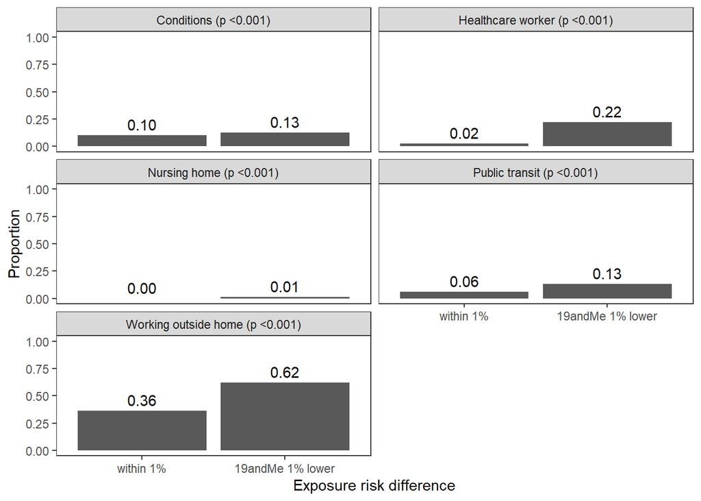

```r
# Process data to get counts for each condition.
temp <- df %>%
  filter(exp_check!="19andMe 1% higher") %>%
  group_by(exp_check) %>%
  dplyr::summarise(#covid_symptoms = sum(is_other),
                   health_worker=sum(health_worker),
                   nursing_home=sum(nursing_home),
                   public_transit=sum(public_transport_count>0),
                   working_outside_home=sum(working %in% c('travel critical', 'travel non critical')),
                   conditions = sum(is_diabetes | is_renal | is_lung | is_cvd),
                   n=n()) %>%
  pivot_longer(health_worker:conditions, names_to='condition', values_to='x') %>%
  mutate(p = x/n) %>%
  arrange(condition)


# Calculate p-values and adjust for multiple comparisons (Bonferroni).
pvals = p.adjust(c(
    prop.test(x =  temp %>% filter(condition=='conditions') %>% pull(x),
            n = temp %>% filter(condition=='conditions') %>% pull(n))$p.value,
    #prop.test(x =  temp %>% filter(condition=='covid_symptoms') %>% pull(x),
    #        n = temp %>% filter(condition=='covid_symptoms') %>% pull(n))$p.value,
    prop.test(x =  temp %>% filter(condition=='health_worker') %>% pull(x),
            n = temp %>% filter(condition=='health_worker') %>% pull(n))$p.value,
    prop.test(x =  temp %>% filter(condition=='nursing_home') %>% pull(x),
            n = temp %>% filter(condition=='nursing_home') %>% pull(n))$p.value,
    prop.test(x =  temp %>% filter(condition=='public_transit') %>% pull(x),
            n = temp %>% filter(condition=='public_transit') %>% pull(n))$p.value,
    prop.test(x =  temp %>% filter(condition=='working_outside_home') %>% pull(x),
            n = temp %>% filter(condition=='working_outside_home') %>% pull(n))$p.value
  ))
temp$pvals = format.pval(rep(pvals, each=2), digits=3, eps=1e-3)
rm(pvals)

# Add labels for conditions.
temp$facets = rep(c(
  'Conditions', 'Healthcare worker', 'Nursing home', 'Public transit', 'Working outside home'), each=2)


ggplot(temp, aes(x=exp_check, y=p, label=format(round(p,2), nsmall=2, digits=2))) +
  geom_bar(stat='identity') +
  geom_text(aes(y=p+.1)) +
  coord_cartesian(ylim=c(0,1)) +
  facet_wrap(~paste0(facets, " (p ", pvals, ')'), ncol=2) +
  labs(x='Exposure risk difference', y = 'Proportion') +
  theme_bw()+
  theme(panel.grid.major = element_blank(), panel.grid.minor = element_blank())
```

```r
ggsave(file.path("..", "figures", "figure-exposure-04.pdf"), height=8, width=8)
```

The following factors appear to be contributing to higher Nexoid exposure risks:

- Working outside the home
- Use of public transit
- Being a healthcare worker
- Having one of the conditions which Nexoid adjusts for

These are not factors that 19andMe considers currently.

## Overall conclusions.

For mortality risk, 19andMe and Nexoid’s calculations are very aligned, and yield largely similar results.

- **98.5%** of cases have a difference of less than 10% for mortality risk.
- **1.46%** of cases have 19andMe mortality risk 10% or more higher than Nexoid’s mortality risk.
  - These cases are all in the 60+ age group,
  - Focused on patients with multiple pre-existing conditions
  - Possibly focused on patients with Covid-19 symptoms, but comparison is difficult.
- **0.03%** of cases, or only 18 observations, have 19andMe mortality risk that is at least 10% lower than Nexoid.
  - These cases are all Black and in the 80+ age group;
  - Matching these cases to similar cases of another race explains these differences.

For exposure risk, 19andMe and Nexoid’s calculations differ, but overall mortality risks are generally similar.

This analysis has focused on similarity of P(exposure) and P(death), as the way that 19andMe and Nexoid present risk scores and labels is fundamentally different. There are benefits to each method.

1. 19andMe presents a single risk score and label (low/middle/high), normalized against risk of the flu.
   - A single combined score gives users one level to interpret.
   - Users have mentioned that our scores seem high - normalization to 50 = same risk of flu may not be intuitive.
   - Score captures risks of exposure, hospitalization, ICU admittance, and death.
2. Nexoid presents two labels; one for risk of infection and one for risk of mortality.
   - More complex for user to interpret.
   - Able to capture more nuanced risk; scenarios where you are very likely to catch Covid, but unlikely to die, and vice versa.
   - Does not capture risk of hospitalization or ICU admittance.